# ESM 206, Assignment 5

Andrew Salvador & Benson Truong

12/2/2019

## Introduction

The Pacific giant salamander, *Dicamptodon tenebrosus*, are large salamanders native to the Pacific Northwest of North America. These salamanders are found around bodies of water such as creeks, ponds, and brooks in forests. Deforestation due to logging is a common threat to the species, so it is important to assess the effects of this disturbance (Johnston et al. 2002). Salamander data was collected at Mack Creek and provided by the Environmental Data Initiative (EDI). The only two measurements used in this report are the counts and weights for the Pacific giant salamander. This study presents annual salamander counts at two different forest sections of Mack Creek (clear cut and old growth), a table of 2017 salamander counts by channel classification, and other visual figures. Specifically, the observations (abundance and weight) of Pacific giant salamanders at each site are analyzed to determine if there is an association between channel classification (pool, cascades, and side-channel) and forest section (old growth and clear cut).

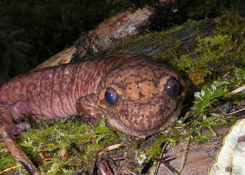

*Figure 1.* *Pacific giant salamander. Credit: [Oregon Wild](https://oregonwild.org/wildlife/pacific-giant-salamander)*.

## Data & Methods

Pacific giant salamanders were captured and weighed at Mack Creek in the H. J. Andrews Experimental Forest and data from 1987 – present were provided by EDI Data Portal (Gregory 2016). 150 m reaches are divided into 3 contiguous 50 m reaches, which are blocked off with nets. Each 50 m sub-reach is then sampled with two-pass electrofishing. For more specific geographic sampling coordinates, see metadata [EDI Data Portal](https://portal.edirepository.org/nis/mapbrowse?scope=knb-lter-and&identifier=4027&revision=12). The abundance and weight were compared at 3 channel classifications for 2 types of forest section by chi-squared test, two sample t-test, Levene’s test, one-way ANOVA and Tukey’s test (α = 0.05 throughout). All analyses and figures were prepared using R software version 3.6.1.

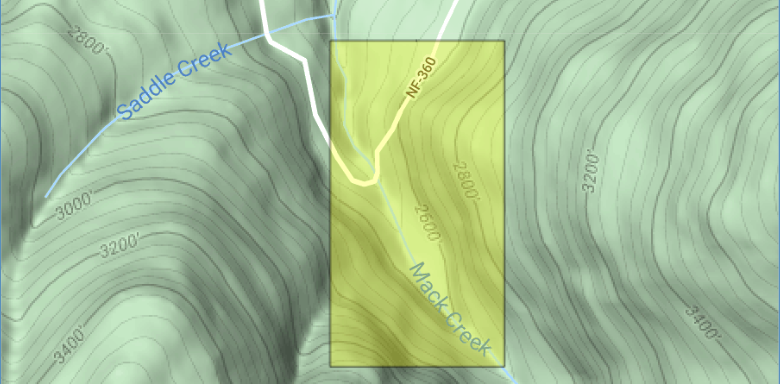

*Figure 2.* *Map of Mack Creek area of study. Credit: [EDI Data Portal](https://portal.edirepository.org/nis/mapbrowse?scope=knb-lter-and&identifier=4027&revision=12).*

## Results

### Results A

#### **Pacific giant salamander abundance**

Salamander count in clear cut (CC) and old growth (OG) sections of Mack Creek from 1993 to 2017. Trends are fairly similar in both sections, with salamander abundance increasing sharply in 2002, decreasing rapidly around the year 2012, and then increasing again beginning in 2015. For all but two years from 1993 to 2014 salamander count in the old growth section was greater than in the clear cut section, with the two exceptions being 1994 and 2012, where salamander count in the clear cut section slightly exceeded salamander observations in the old growth section. Salamander count in the clear cut section was greater than in the old growth section for all three years from 2015 to 2017.

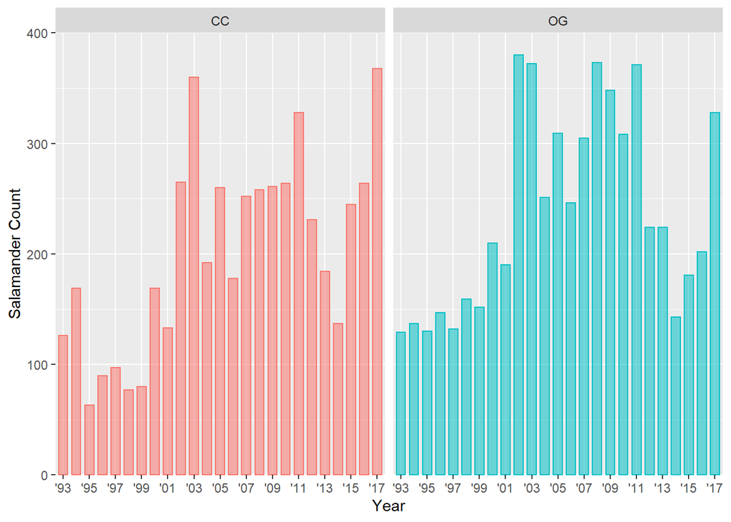

*Figure 3.* *Sample salamander counts from years 1993 to 2017 for clear cut (CC) and old growth (OG) sections of Mack Creek. Clear cut section shown in red while old growth section shown in blue. Data: Aquatic Vertebrate Population Study in Mack Creek, Andrews Experimental Forest, 1987 to present.*

### Results B

*Table 1.* *Counts and proportions of salamanders observed in different channel classifications (cascades, pool, side-channel) within two different sections (clear cut & old growth) in Mack Creek in 2017. Table excludes salamanders observed in isolated pools (IP) disconnected from the channel. Data: Aquatic Vertebrate Population Study in Mack Creek, Andrews Experimental Forest, 1987 to present.*

| Section | Cascades | Pool | Side-Channel |
| --- | --- | --- | --- |
| Clear Cut | 247 (67.12%) | 31 (8.42%) | 90 (24.46%) |
| Old Growth | 201 (62.81%) | 45 (14.06%) | 74 (23.12%) |

### Results C

#### **Forest condition impact on Pacific giant salamander location in 2017**

From Chi-squared test, forest condition (clear cut or old growth) did not have a significant effect on salamander location within the channel (cascade, side-channel, pool) (($\chi$<sup>2</sup>(2)) = 5.5412722), *p* > 0.05). For salamander observations in the clear cut section n = 368, for observations in the old growth section n = 320. The greatest proportion of salamanders observed was in cascades (67.12% clear cut, 62.81% old growth), while the smallest proportion of salamanders observed was in pools (8.42% clear cut, 14.06% old growth). Actual counts for clear cut areas were 247 in cascades, 31 in pools, and 90 in side-channels, and for old growth forest, 201 in cascades, 45 in pools, and 74 in side-channels (Table 1).

### Results D

#### **Comparing Pacific giant salamander weight in 2017**

Mean salamander weight in clear cut and old growth sections did not differ significantly in 2017 (t(692.79) = -1.67, *p* > 0.05). Mean salamander weight in the clear cut section was 18.11% greater than in the old growth section, with an actual difference of 1.19 grams. For salamanders observed in the clear cut section, mean = 7.78g, n = 368, while for salamanders observed in the old growth section, mean = 6.58g, n = 320.

### Results E

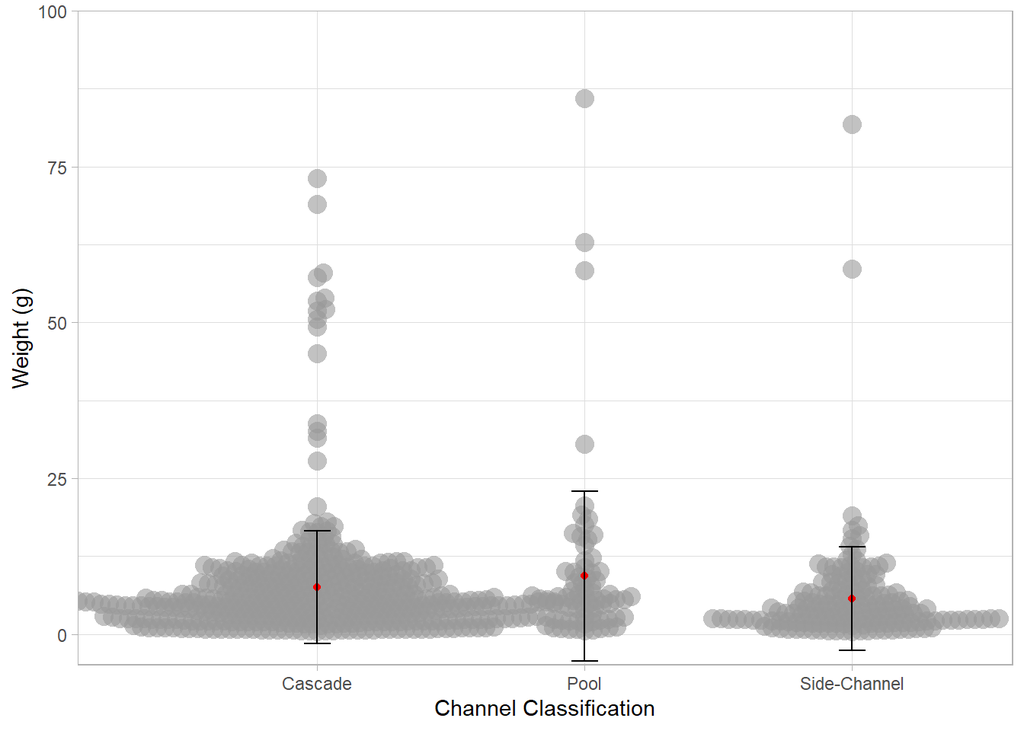

*Figure 4.* *Salamander weight (g) for cascade (n = 448), pool (n = 76), and side-channel (n = 164) in Mack Creek, Oregon. Means indicated by red dots; error bars indicate $\pm$ 1 standard deviation. Cascade standard error = 0.43, pool standard error = 1.56, and side-channel standard error = 0.65. Data: Aquatic Vertebrate Population Study in Mack Creek, Andrews Experimental Forest, 1987 to present.*

One concern about comparing means across these groups is that when using a histogram and qq-plot to check for normality, the distribution of the means does not look perfectly normal. Another possible analysis to consider doing would be a Mann-Whitney U test for an unpaired rank based comparison.

## References

**Gregory, S. V. (2016).** *Aquatic Vertebrate Population Study in Mack Creek, Andrews Experimental Forest, 1987 to present.* Environmental Data Initiative. https://doi.org/10.6073/pasta/5de64af9c11579266ef20da2ff32f702. Dataset accessed 11/30/2019.

**Johnston, B. and Frid, L (2002).** *Clearcut logging restricts the movements of terrestrial Pacific giant salamanders (Dicamptodon tenebrosus Good).* Canadian Journal of Zoology. 80(20): 2170-2177.